# Pond Metabolism Example

Audrey H. Goeckner

2024-06-27

This R markdown is an example of modeling pond metabolism using 1 month of data (August 2022) from pond Meandering Way, a site in my 3rd chapter. We model pond metabolism using the LakeMetabolizer package (Winslow et al. 2016), and functions of the rLakeAnalyzer package (Winslow et al. 2019).

I built/modified this script from the tutorial I found online through a workshop hosted by GLEON (Global Lake Observatory Network) and run by Corinna Gries & Hilary Dugan: https://g11.gleon.org/data/gleon18/dataworkshop\

For our work, we collected thermal temperature profiles using thermistor chain with temp/light sensors throughout the water column. This pond was ~4 to 4.5 m deep and we had sensors down to 3 m deep. We did not use a pressure transducer to keep track of water level fluctuations.

This example uses a maximum likelihood model (MLE) to estimate pond metabolism. There is a bayesian approach I’d like to try in the future.

As a note, you’ll see that I use lapply or do.call when I read in raw .csv files. I do this to combine the multiple files gained over time for a single sensor. In this example there is only one file per sensor, but I keep the lapply/do.call functions so they can be adapted.

This is unfinished! Still to come:

- Assessing estimated MLE parameters
- Assessing estimated versus observed dissolved oxygen readings

# Getting started

### Libraries

```r
library(rLakeAnalyzer) #lake parameters
library(LakeMetabolizer) #metabolism package
library(lubridate) #working with time
library(tidyverse)
```

### Directories

```r
#working directory
setwd("/Users/audreygoeckner/Library/CloudStorage/OneDrive-UniversityofFlorida/Goeckner_R_Projects/Pond_Metabolism")

#path for raw data in this example.
#I set my paths as values sto easily change directories in this one spot
path.rawData = "./raw_data"
```

### Basic pond parameters

These details are needed later in various equations throughout. I like to include this up at the top so I can enter in all my pond info in one spot

```r
#Area of pond in square meters (m^2)
pond.area = 7075

#Altitude of pond above sea level in meters (m)
pond.alt = 9

#Latitude of pond in decimal degrees
pond.latitude = 27.4

#Height above water surface you measured wind speed in meters (m)
wnd.z = 2
```

# Weather/atmospheric data

```r
weather_15 <-
list.files(path = "./raw_data", pattern = "weatherData", #list files in path that match the pattern
           full.names = TRUE) %>% #full.names extracts the full file name that matches your pattern
  lapply(read.csv, skip=2, header=FALSE) %>% #read.csv all listed files, skip the first 2 rows
  bind_rows() %>% select(-1) %>% #bind files by rows, remove the first column, which is row #s
   rename("datetime" = 1, "atm.temp.F" = 2, "RH" = 3, #renaming the rows
          "wind.mph" = 4, "gust.mph" = 5, "wind.dir" = 6, "bp.inHg" = 7) %>%
  mutate(atm.temp.C = round(((atm.temp.F-32)/1.8),digits=2), # convert temp in F to C
         datetime = as.POSIXct(datetime, format ="%m/%d/%y %H:%M")) # format date and time

#review
head(weather_15)
```

```
##              datetime atm.temp.F    RH wind.mph gust.mph wind.dir bp.inHg
## 1 2022-08-01 00:00:00      82.39 77.22     0.25     2.25   122.13   30.15
## 2 2022-08-01 00:15:00      82.14 78.22     0.49     1.99   142.23   30.15
## 3 2022-08-01 00:30:00      81.45 79.85     0.00     0.99   130.10   30.15
## 4 2022-08-01 00:45:00      81.09 80.69     0.25     1.49   129.63   30.14
## 5 2022-08-01 01:00:00      80.93 81.32     0.49     1.99   155.37   30.14
## 6 2022-08-01 01:15:00      80.62 82.05     0.25     1.75   135.70   30.14
##   atm.temp.C
## 1      27.99
## 2      27.86
## 3      27.47
## 4      27.27
## 5      27.18
## 6      27.01
```

# Thermistor chain data

### Thermal profiles

I know that there is a shorter way to import and combine thermistor files for each depth using loops but I haven’t put time into it yet. Each do.call() call is for a different sensor. Each sensor file is row binded by there various files over time, then I add a column defining depth.

```r
#confirm all desired files are included for a depth
list.files(path=path.rawData, pattern="0.00")
```

```
## [1] "PMW_therm_0.00m_20220801-202208.csv"
```

```r
#combining thermistor chain data
therm_5 <-
  rbind(
  do.call(rbind, lapply(list.files(path=path.rawData, pattern="0.00",full.names = TRUE), read.csv, header=FALSE,skip=2)) %>% mutate(depth="0"),
  do.call(rbind, lapply(list.files(path=path.rawData, pattern="*0.25",full.names = TRUE), read.csv, header=FALSE,skip=2)) %>% mutate(depth="0.25"),
    do.call(rbind, lapply(list.files(path=path.rawData, pattern="0.50",full.names = TRUE), read.csv, header=FALSE,skip=2)) %>% mutate(depth="0.50"),
    do.call(rbind, lapply(list.files(path=path.rawData, pattern="0.75",full.names = TRUE), read.csv, header=FALSE,skip=2)) %>% mutate(depth="0.75"),
    do.call(rbind, lapply(list.files(path=path.rawData, pattern="1.00",full.names = TRUE), read.csv, header=FALSE,skip=2)) %>% mutate(depth="1.00"),
    do.call(rbind, lapply(list.files(path=path.rawData, pattern="1.25",full.names = TRUE), read.csv, header=FALSE,skip=2)) %>% mutate(depth="1.25"),
    do.call(rbind, lapply(list.files(path=path.rawData, pattern="1.50",full.names = TRUE), read.csv, header=FALSE,skip=2)) %>% mutate(depth="1.50"),
    do.call(rbind, lapply(list.files(path=path.rawData, pattern="1.75",full.names = TRUE), read.csv, header=FALSE,skip=2)) %>% mutate(depth="1.75"),
    do.call(rbind, lapply(list.files(path=path.rawData, pattern="2.00",full.names = TRUE), read.csv, header=FALSE,skip=2)) %>% mutate(depth="2.00"),
    do.call(rbind, lapply(list.files(path=path.rawData, pattern="3.00",full.names = TRUE), read.csv, header=FALSE,skip=2)) %>% mutate(depth="3.00")
  ) %>%
  select(-1) %>% rename(datetime=1,wtemp.F=2,sol.lumft2=3) %>% #remove column 1 and rename
  mutate(depth = as.factor(depth), #depth as a factor
         temp.C = round(((wtemp.F-32)/1.8),digits=2), #calculating water temp in C
         datetime = as.POSIXct(datetime, format = "%m/%d/%y %H:%M",tz="UTC"), #format date
         date = as.Date(datetime)) %>% #day of obs
  filter(!date == "2022-08-18") #removing the one date we maintained sensors within this example time frame

#review
head(therm_5)
```

```
##              datetime wtemp.F sol.lumft2 depth temp.C       date
## 1 2022-08-01 00:00:00  92.174          0     0  33.43 2022-08-01
## 2 2022-08-01 00:05:00  92.174          0     0  33.43 2022-08-01
## 3 2022-08-01 00:10:00  91.987          0     0  33.33 2022-08-01
## 4 2022-08-01 00:15:00  91.987          0     0  33.33 2022-08-01
## 5 2022-08-01 00:20:00  91.800          0     0  33.22 2022-08-01
## 6 2022-08-01 00:25:00  91.800          0     0  33.22 2022-08-01
```

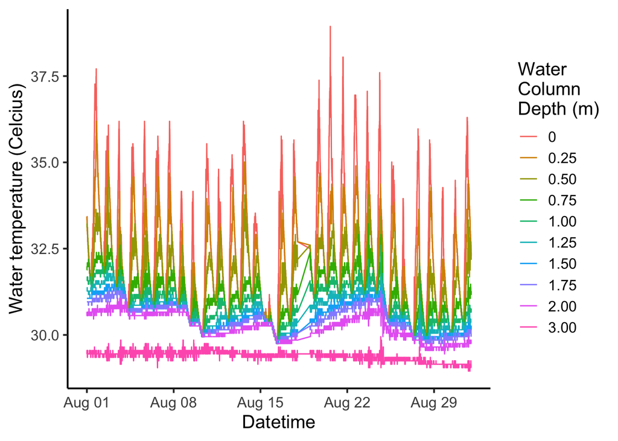

```r
#check for anomalies in data
ggplot(therm_5, aes(x = datetime, y = temp.C, color = depth)) +
  geom_line() + theme_classic(base_size = 15)+
  labs(y = "Water temperature (Celcius)", x = "Datetime", color = "Water \nColumn \nDepth (m)")
```

```r
#none here!



#average observations to get 15-minute interval data
therm_15 <- therm_5 %>%
  mutate(by15 = cut(datetime, breaks="15 min")) %>%
  group_by(by15,depth) %>%
  summarise_all(.funs = mean) %>%
  ungroup() %>% select(-by15) %>%
  mutate(datetime = datetime - 5*60) #subtract 5 min so times are in 00:00, 15:00, 30:00, 45:00 intervals



#Convert data from long to wide format
therm_15_wide <- therm_15 %>%
  select(datetime, depth, temp.C) %>%
  spread(depth,temp.C) # convert dataset from 'long' format to 'wide, only do two col.

#Convert the colnames of the data to include ‘wtemp.C_’
colnames(therm_15_wide)[-1] = paste('temp.C_', colnames(therm_15_wide)[-1], sep='')

#tibble to dataframe
therm_15_wide <- as.data.frame(therm_15_wide)

#review
head(therm_15_wide)
```

```
##              datetime temp.C_0 temp.C_0.25 temp.C_0.50 temp.C_0.75 temp.C_1.00
## 1 2022-08-01 00:00:00 33.39667    33.43000    33.18667    31.88000    31.57000
## 2 2022-08-01 00:15:00 33.25667    33.33000    33.15333    31.98000    31.57000
## 3 2022-08-01 00:30:00 33.15333    33.18667    33.22000    31.98000    31.60667
## 4 2022-08-01 00:45:00 33.04667    33.08333    33.12000    32.01667    31.68000
## 5 2022-08-01 01:00:00 32.94333    33.01000    33.04667    32.09000    31.68000
## 6 2022-08-01 01:15:00 32.87667    32.91000    32.94333    32.09000    31.60667
##   temp.C_1.25 temp.C_1.50 temp.C_1.75 temp.C_2.00 temp.C_3.00
## 1    31.27000       31.06       30.96    30.62667    29.48333
## 2    31.27000       31.06       30.96    30.56000    29.48333
## 3    31.30333       31.06       30.96    30.59333    29.45000
## 4    31.27000       31.06       30.96    30.56000    29.41667
## 5    31.27000       31.06       30.96    30.56000    29.35000
## 6    31.27000       31.06       30.96    30.56000    29.45000
```

```r
#check to see if there are any missing data - should be non
which(is.na(therm_15_wide)) #none!
```

```
## integer(0)
```

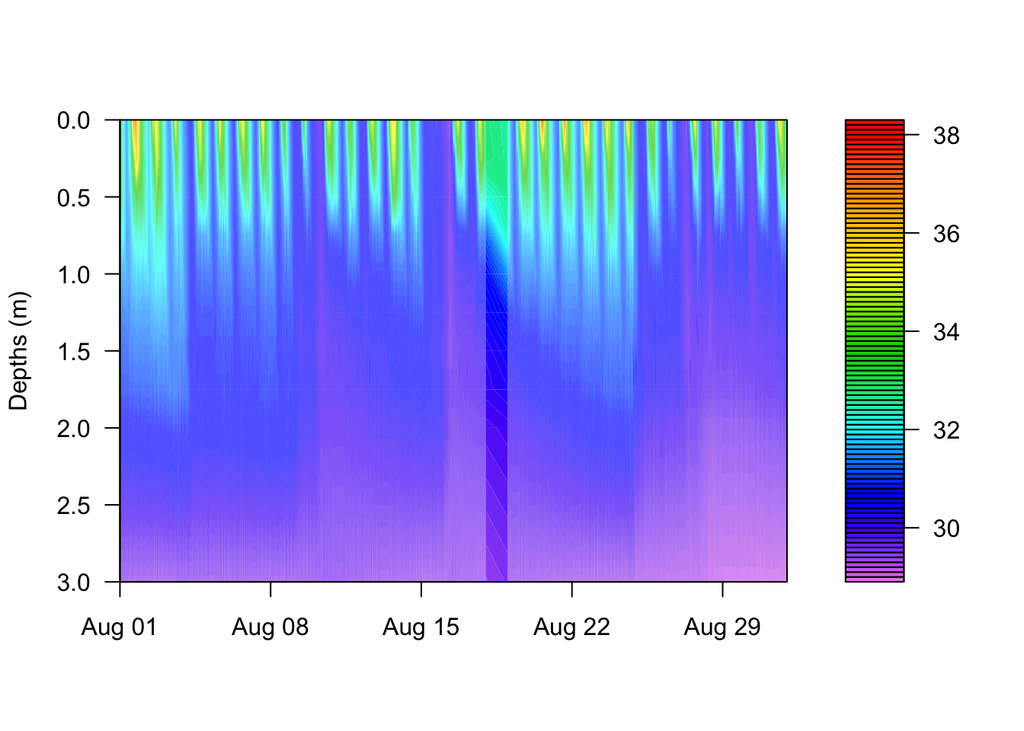

```r
#check out the heat map! You can see how the data is interpolated for the date removed, 8/18
wtr.heat.map(therm_15_wide)
```

### Mixing depth

Calculate the depth of the mixing layer (zmix) using thermal profiles. When the water column is mixed and there is no mixing depth, zmix will return “NA”. In this case I convert all NA to the max depth of the pond

```r
#pond depth in meters
pond.depth = 4.0

#z.mix depth
zmix =
  ts.thermo.depth(wtr = therm_15_wide, na.rm = T) %>% #zmix output is a column "thermo.depth"
  mutate(zmix = case_when(is.na(thermo.depth)~pond.depth, TRUE~thermo.depth)) %>% #if NA, replace with max depth, otherwise keep zmix
  select(-thermo.depth) #remove thermo.depth column

#review
head(zmix)
```

```
##              datetime     zmix
## 1 2022-08-01 00:00:00 1.953330
## 2 2022-08-01 00:15:00 1.921731
## 3 2022-08-01 00:30:00 1.938447
## 4 2022-08-01 00:45:00 1.928299
## 5 2022-08-01 01:00:00 1.935375
## 6 2022-08-01 01:15:00 1.924955
```

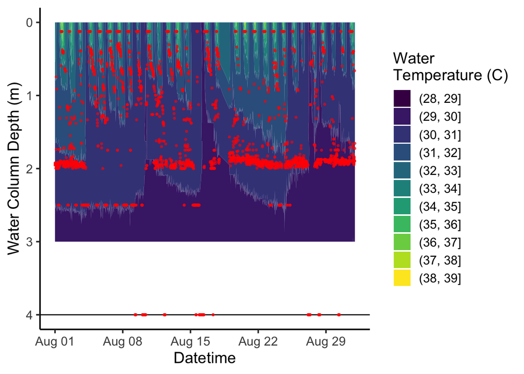

```r
#compare thermal profiles and calculated mixing depths
ggplot(therm_15, aes(x = datetime, y = as.numeric(as.character(depth))))+
  geom_contour_filled(aes(z = temp.C))+
  geom_hline(yintercept = pond.depth)+
  geom_point(data = zmix, aes(x = datetime, y = zmix), color = "red", alpha = 0.6, size = 0.7)+
  scale_y_reverse()+
  theme_classic(base_size = 15)+
  labs(x = "Datetime", y = "Water Column Depth (m)", fill = "Water \nTemperature (C)")
```

### Photosynthetically active radiation (par)

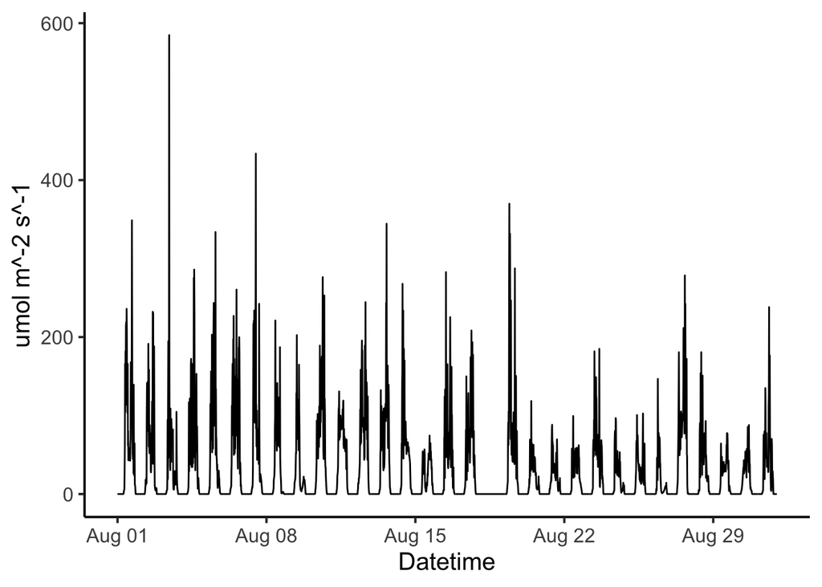

```r
#light data
light_15_0.25m <-
  therm_15 %>%
  filter(depth == "0.25") %>%
  mutate(par = sol.lumft2*10.764/54) %>% #I checked this conversion with chat gpt
  select(datetime,par)


#check to make sure light data make sense
ggplot(light_15_0.25m, aes(x = datetime, y = par)) +
  geom_line()+
  theme_classic(base_size = 15)+
  labs(x = "Datetime", y = "umol m^-2 s^-1")
```

# Dissolved Oxygen

### Gas saturation functions

These functions are used for calculating O2 saturation. Some have been updated from those shared with us from folks Bob Hall’s lab

```r
###########################################
# Correct BAROMETRIC PRESSURE for altitude
###########################################
### bpcalc function estimates barometric pressure (BP) given altitude and standard BP. This is the "bp" required for O2 sat. This is based on the barometric formula
### temp = degC for the water
### alt = elevation in m
### bpst = standard barometric pressure in inches of Hg (untis usually given by weather websites).
### Temp is usually relative to a standard, 15 degC, and I have hard coded it at 15.
### Source: John Colt, Dissolved Gas Concentration in Water: Computation as Functions of Temperature, Salinity and Pressure, 2012

#when bp input is in inches mercury
bpcalc.inHg<- function(bpst, alt) {
  bpst*25.4*exp((-9.80665*0.0289644*alt)/(8.31447*(273.15+15))) #25.4 converts inHg to mmHg, 288.15 is standard pressure at sea level
}

#when bp input is in mm mercury
bpcalc.mmHg<- function(bpst, alt) {
  bpst*exp((-9.80665*0.0289644*alt)/(8.31447*(273.15+15)))
}
#####

###########################################
# Calculate WATER DENSITY w/ Temp and BP
###########################################
#Water density of air saturated water given water temperature in degC.
#Equation updated by AG  - the International Committee for Weights and Measures (2001), who consider Patterson&Morris (1994), who Bob cited
#https://metgen.pagesperso-orange.fr/metrologieen19.htm

watdens.gcm3<-function(temp){
  t<-temp
  a1<- -3.983035  # degrees C
  a2<- 301.797    # degrees C
  a3<- 522528.9   # degrees C
  a4<- 69.34881   # degrees C
  a5<- 999.974950 # kg/m^3

  dens<- a5 * (1-(((t + a1)^2 * (t + a2))/(a3 * (t + a4)))) #returns result as kg/m^3
  dens/1000   #converts kg/m^3 -> g/cm^3
}
#####

###########################################
# Calculate O2 SATURATION w/ Temp and BP
###########################################
### Oxygen saturation. Alternative formulation from Garcia and Gordon (umol/kg), which is converted to mg/L and corrected for water density.
### This function gives the same values as from Colt and is the one a MIMSer should use.
### u is the vapor pressure of water
### Ending units mg/L

osat.mgL<- function(temp, bp) {
  u<-10^(8.10765-(1750.286/(235+temp)))
  ts<-log((298.15-temp) / (273.15 + temp))
  a0<-5.80871
  a1<-3.20291
  a2<-4.17887
  a3<-5.1006
  a4<- -9.86643e-2
  a5<-3.80369

  u<-10^(8.07131-(1750.63/(233.426+temp))) #Antoine equation for the vapor pressure of water, final unit mmHg
  sato<-(exp(a0 + a1*ts + a2*ts^2 + a3*ts^3 + a4*ts^4 + a5*ts^5))*((bp-u)/(760-u))
  watdens.gcm3(temp)*sato*(31.9988/1000)##converts umol/kg to mg/L
}
```

```r
#raw 5 minute data
DOraw_5 <-
  do.call(rbind,lapply(list.files(path=path.rawData, pattern="DOdata.*\\.csv$", full.names = TRUE), #list all csv files of a pattern
                 read.csv, skip=2, header=FALSE)) %>% select(-1) %>% #read.csv for listed files, remove first row, remove first column, rowbind
  rename(datetime = 1,DO.mgL = 2, temp.F = 3) %>% #rename columns
  mutate(temp.C = ((temp.F-32)/1.8), #calculate water temp as Celsius
         datetime = as.POSIXct(datetime, format = "%m/%d/%y %H:%M",tz="UTC"), #date formatting
         across(everything(), function(x){replace(x, which(x<0), NA)}), #replace error readings "-888" or below 0 with NA
         date = as.Date(datetime)) %>% #day from datetime
  filter(!date == "2022-08-18") #removing sensor maintenance dates

#review
head(DOraw_5)
```

```
##              datetime DO.mgL temp.F   temp.C       date
## 1 2022-08-01 00:00:00   6.80  91.80 33.22222 2022-08-01
## 2 2022-08-01 00:05:00   6.78  91.72 33.17778 2022-08-01
## 3 2022-08-01 00:10:00   6.71  91.65 33.13889 2022-08-01
## 4 2022-08-01 00:15:00   6.54  91.58 33.10000 2022-08-01
## 5 2022-08-01 00:20:00   6.76  91.47 33.03889 2022-08-01
## 6 2022-08-01 00:25:00   6.21  91.44 33.02222 2022-08-01
```

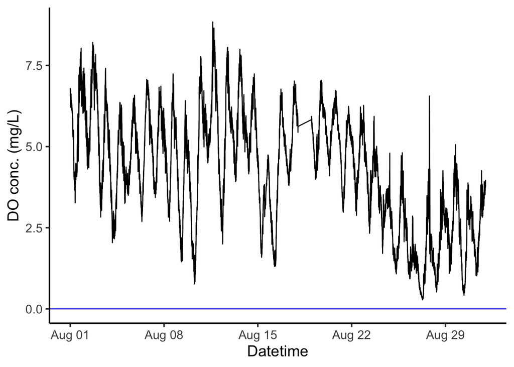

```r
#check for weird data
ggplot(DOraw_5, aes(x=datetime, y=DO.mgL))+
  geom_line()+
  geom_hline(yintercept = 0, color = "blue")+
  theme_classic(base_size = 15)+
  labs(x = "Datetime", y = "DO conc. (mg/L)")
```

```r
#average raw data to 15 minutes
DOraw_15 <-DOraw_5 %>%
  mutate(by15 = cut(datetime, breaks="15 min")) %>%
  group_by(by15) %>%
  summarise_all(.funs = mean,na.rm=TRUE) %>%
  ungroup() %>% select(-by15) %>%
  mutate(datetime = datetime - 5*60) #subtract 5 min so times are in 00:00, 15:00, 30:00, 45:00 intervals

#review
head(DOraw_15)
```

```
## # A tibble: 6 × 5
##   datetime            DO.mgL temp.F temp.C date
##   <dttm>               <dbl>  <dbl>  <dbl> <date>
## 1 2022-08-01 00:00:00   6.76   91.7   33.2 2022-08-01
## 2 2022-08-01 00:15:00   6.50   91.5   33.1 2022-08-01
## 3 2022-08-01 00:30:00   6.49   91.3   33.0 2022-08-01
## 4 2022-08-01 00:45:00   6.35   91.1   32.8 2022-08-01
## 5 2022-08-01 01:00:00   6.52   91.0   32.8 2022-08-01
## 6 2022-08-01 01:15:00   6.35   90.8   32.7 2022-08-01
```

```r
#We run into issues when there are NAs at the 15 minute average mark
#if there are any, I use the average of the previous and following reading.
#look at NA values for DO
DOraw_15[is.na(DOraw_15$DO.mgL),]
```

```
## # A tibble: 0 × 5
## # ℹ 5 variables: datetime <dttm>, DO.mgL <dbl>, temp.F <dbl>, temp.C <dbl>,
## #   date <date>
```

```r
#none


#merge DO and weather data
DO.weather_15 <- merge(DOraw_15, weather_15, by="datetime") %>%
  mutate(date = as.Date(datetime),
         O2sat.expected = osat.mgL(temp.C,bp = bpcalc.inHg(bp.inHg, alt = pond.alt)),
         DO.perc=(DO.mgL/O2sat.expected)*100)

#review
head(DO.weather_15)
```

```
##              datetime   DO.mgL   temp.F   temp.C       date atm.temp.F    RH
## 1 2022-08-01 00:00:00 6.763333 91.72333 33.17963 2022-08-01      82.39 77.22
## 2 2022-08-01 00:15:00 6.503333 91.49667 33.05370 2022-08-01      82.14 78.22
## 3 2022-08-01 00:30:00 6.493333 91.31333 32.95185 2022-08-01      81.45 79.85
## 4 2022-08-01 00:45:00 6.346667 91.12667 32.84815 2022-08-01      81.09 80.69
## 5 2022-08-01 01:00:00 6.520000 90.95667 32.75370 2022-08-01      80.93 81.32
## 6 2022-08-01 01:15:00 6.353333 90.82333 32.67963 2022-08-01      80.62 82.05
##   wind.mph gust.mph wind.dir bp.inHg atm.temp.C O2sat.expected  DO.perc
## 1     0.25     2.25   122.13   30.15      27.99       7.211083 93.79081
## 2     0.49     1.99   142.23   30.15      27.86       7.226236 89.99614
## 3     0.00     0.99   130.10   30.15      27.47       7.238529 89.70515
## 4     0.25     1.49   129.63   30.14      27.27       7.248572 87.55748
## 5     0.49     1.99   155.37   30.14      27.18       7.260029 89.80680
## 6     0.25     1.75   135.70   30.14      27.01       7.269036 87.40269
```

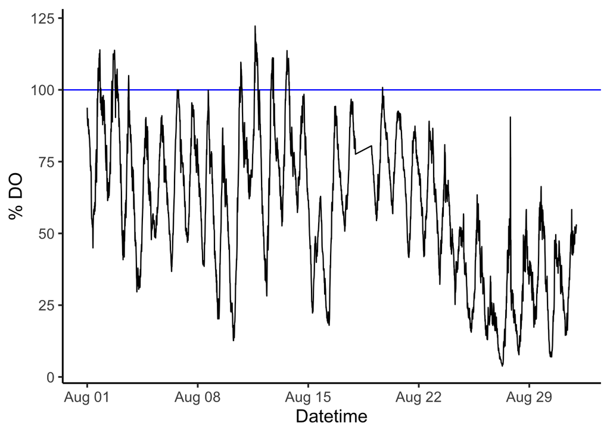

```r
#check data - % dissolved oxygen saturation
ggplot(DO.weather_15, aes(x=datetime, y=DO.perc))+
  geom_hline(yintercept = 100, color = "blue")+
  geom_line()+
 # scale_x_datetime(date_labels = "%b", date_breaks = "1 month")+
  theme_classic(base_size = 15)+
  labs(x = "Datetime", y = "% DO")
```

# Model parameters and gas transfer

First I’m going to merge the light and zmix data into one dataset. Helpful for saving everything together later.

```r
#adding light data
pondData_15 <- merge(DO.weather_15, light_15_0.25m, by="datetime")
#adding zmix data
pondData_15 <- merge(pondData_15, zmix, by="datetime")

#check if there are any duplicated days (this happened to me before, maybe a time change issue?)
isTRUE(duplicated(pondData_15$datetime))
```

```
## [1] FALSE
```

```r
#no duplicated days
```

### Gas transfer velocity (K; vars 7-8)

Here I calculate and comparing two common K vars used for small ponds versus larger lakes. Feel free to try out others, but these are more appropriate for smaller systems. For N2 fluxes, Zhang et al. (2022), used an approach that found the cole equation was best for their ponds.

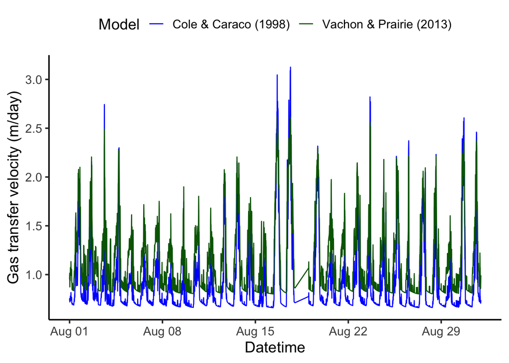

```r
#7. Scaled wind speed. Scaled to standard U10 (10 m above the water surface) based on height of observation
pondData_15$U10 = wind.scale.base(wnd = pondData_15$wind.mph,
                      wnd.z = wnd.z) # height above water you recorded wind speed


#the ".base" function within each ".kGAS" functions returns the gas exchange velocity based on the chosen model in units of m/day
#the ".kGAS" function then returns the gas exchange velocity for the specific gas of interest w/ no unit conversions (m/day)

#8a. Cole & Caraco (1998) equation (only wind based)
pondData_15$kgas.cole = k600.2.kGAS.base(temperature = pondData_15$temp.C, #water temperature
                             gas = "O2", #gas of interest (can do CO2)
                             k600 = k.cole.base(pondData_15$U10) #k600; scaled wind speed
                             )

#8b. Vachon & Prairie (2013) equation (emphasizes size and shape of water body)
pondData_15$kgas.vachon = k600.2.kGAS.base(temperature = pondData_15$temp.C, #water temperature
                               gas = "O2", #gas of interest
                               k600 = k.vachon.base(wnd = pondData_15$U10, #k600; scaled wind speed
                                             lake.area = pond.area, #area of pond
                                             params = c(2.51,1.48,0.39))) #model parameters that were considered the best in the paper

#You will get a warning about temperature. This is because the Schmidt # is only for temepratures in the range of 0-30 C. I have yet to consult others about their approach for 30+ temps (we have up to 37.2 in this dataset)


#plot gas transfer velocities
ggplot(data = pondData_15, aes(x = datetime))+
  geom_line(aes(y = kgas.cole, color = "blue"))+
  geom_line(aes(y = kgas.vachon, color = "darkgreen"))+
  theme_classic(base_size = 15)+
  labs(y = "Gas transfer velocity (m/day)", x = "Datetime")+
  scale_colour_manual(name = 'Model',labels = c('Cole & Caraco (1998)','Vachon & Prairie (2013)'),
         values =c('blue'='blue','darkgreen'='darkgreen'))+
  theme(legend.position = "top")
```

# Modeling Pond Metabolism

### Modified metabolism function

We use a maximum likelihood model to estimate pond metabolism. Following the online tutorial by Hilary Dugan, we create our own function for producing a metabolism ouput, and I modify it further to include all metabolic rates and MLE model parameter estimates for each day.

```r
metab.mle.estimates <- function(data, do.obs, do.sat, k.gas, z.mix, wtr, par, error.type) {
# Setup empty data.frame for three months
output = data.frame(date = as.Date(unique(data$date)))

# Loop through each day.
for (i in 1:nrow(output)) {

# Create a index for each day, so only those days values will be used
indx <- as.Date(data$datetime) == output$date[i]

m.mle = metab.mle(do.obs[indx], do.sat[indx], k.gas[indx], z.mix[indx],par[indx],wtr[indx], error.type = error.type)

output$GPP[i] = round(m.mle$metab[1],3)
output$ER[i] = round(m.mle$metab[2],3)
output$NEP[i] = round(m.mle$metab[3],3)
output$GPP.coef[i] = round(m.mle$params[1],3)
output$ER.coef[i] = round(m.mle$params[2],3)
output$Q[i] = round(m.mle$params[3],3)
output$nll[i] = round(m.mle$params[4],3)
}
return(output)
}
```

### Modeling with two gas transfer coefficients

```r
#metabolism using the Cole & Caraco (1998) gas transfer
pondMetabolism.cole <- pondData_15 %>%
  metab.mle.estimates(do.obs = .$DO.mgL, #observations of DO in mg/L
                      do.sat = .$O2sat.expected, #expected DO saturation
                      z.mix = .$zmix, #mixing layer depth
                      wtr = .$temp.C, #water temperature at the DO sensor (AKA HOBO temp)
                      k.gas = .$kgas.cole, #choice of gas transfer
                      par = .$par, #photosynthetically active radiation
                      error.type = "PE") #process error, other option is "OE" or observation error
#review
head(pondMetabolism.cole)
```

```
##         date    GPP     ER    NEP GPP.coef ER.coef     Q     nll
## 1 2022-08-01  3.957 -4.787 -0.831    0.001  -0.014 0.077  13.367
## 2 2022-08-02  2.613 -2.647 -0.035    0.001  -0.008 0.076  12.541
## 3 2022-08-03  1.587 -6.090 -4.503    0.001  -0.018 0.074  11.476
## 4 2022-08-04  0.911 -6.142 -5.231    0.000  -0.018 0.054  -3.575
## 5 2022-08-05 -0.369 -3.578 -3.947    0.000  -0.011 0.033 -27.239
## 6 2022-08-06  2.519 -6.388 -3.869    0.001  -0.019 0.025 -40.460
```

```r
#metabolism using the Vachon & Prairie (1998) gas transfer
pondMetabolism.vachon <- pondData_15 %>%
  metab.mle.estimates(do.obs = .$DO.mgL, #observations of DO in mg/L
                      do.sat = .$O2sat.expected, #expected DO saturation
                      z.mix = .$zmix, #mixing layer depth
                      wtr = .$temp.C, #water temperature at the DO sensor (AKA HOBO temp)
                      k.gas = .$kgas.vachon, #choice of gas transfer
                      par = .$par, #photosynthetically active radiation
                      error.type = "PE") #process error, other option is "OE" or observation error

#review
head(pondMetabolism.vachon)
```

```
##         date    GPP     ER    NEP GPP.coef ER.coef     Q     nll
## 1 2022-08-01  3.878 -4.936 -1.058    0.001  -0.015 0.076  12.760
## 2 2022-08-02  2.570 -2.787 -0.217    0.001  -0.008 0.076  12.553
## 3 2022-08-03  1.487 -6.688 -5.201    0.000  -0.020 0.075  11.598
## 4 2022-08-04  0.210 -7.160 -6.950    0.000  -0.021 0.055  -2.802
## 5 2022-08-05 -1.152 -4.221 -5.373    0.000  -0.013 0.033 -27.173
## 6 2022-08-06  1.759 -7.100 -5.340    0.000  -0.021 0.026 -38.359
```

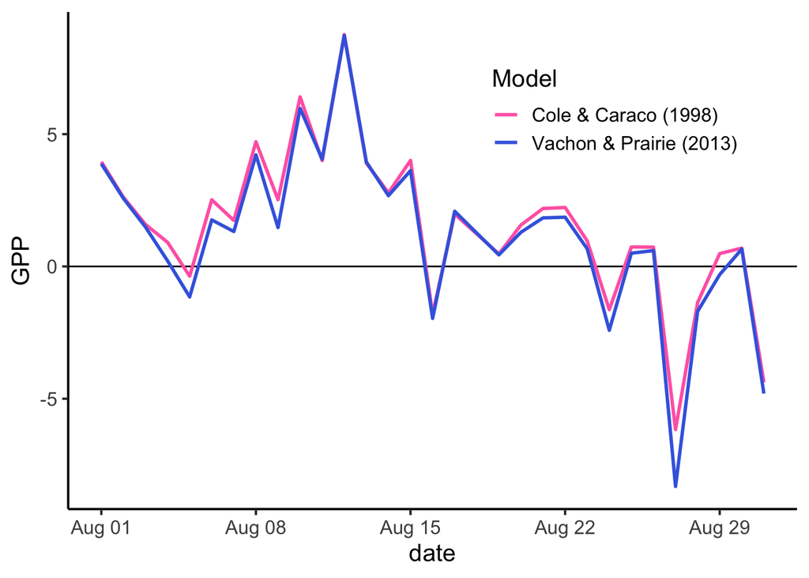

```r
#Check output in plots and compare the two gas transfer velocities

#GPP
ggplot(pondMetabolism.cole, aes(x = date, y = GPP))+
  geom_hline(yintercept = 0)+
  geom_line(aes(color = "hotpink"), size=1)+
  geom_line(data =  pondMetabolism.vachon, aes(x = date, y = GPP, color = "royalblue"), linewidth=1)+
  scale_color_manual(name = 'Model',labels = c('Cole & Caraco (1998)','Vachon & Prairie (2013)'),
         values =c('hotpink'='hotpink','royalblue'='royalblue'))+
  theme_classic(base_size = 15) + theme(legend.position = c(0.75,0.8))
```

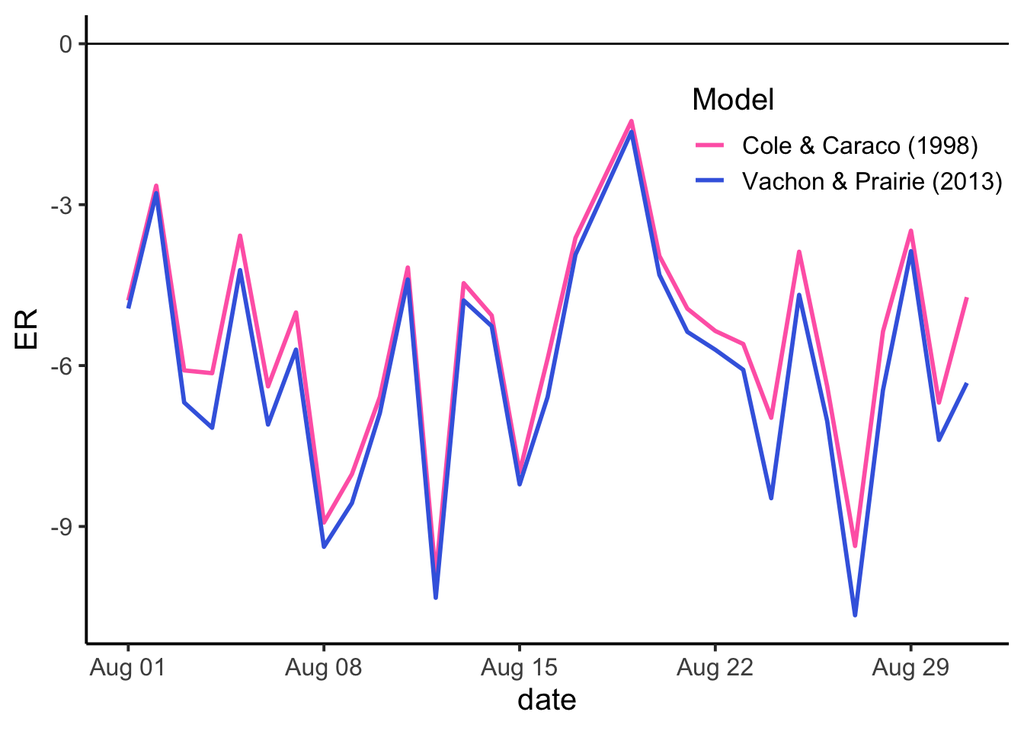

```r
#some impossible values here (negative GPP)

#ER
ggplot(pondMetabolism.cole, aes(x = date, y = ER))+
  geom_hline(yintercept = 0)+
  geom_line(aes(color = "hotpink"), size=1)+
  geom_line(data =  pondMetabolism.vachon, aes(x = date, y = ER, color = "royalblue"), linewidth=1)+
  scale_color_manual(name = 'Model',labels = c('Cole & Caraco (1998)','Vachon & Prairie (2013)'),
         values =c('hotpink'='hotpink','royalblue'='royalblue'))+
  theme_classic(base_size = 15) + theme(legend.position = c(0.825,0.8))
```

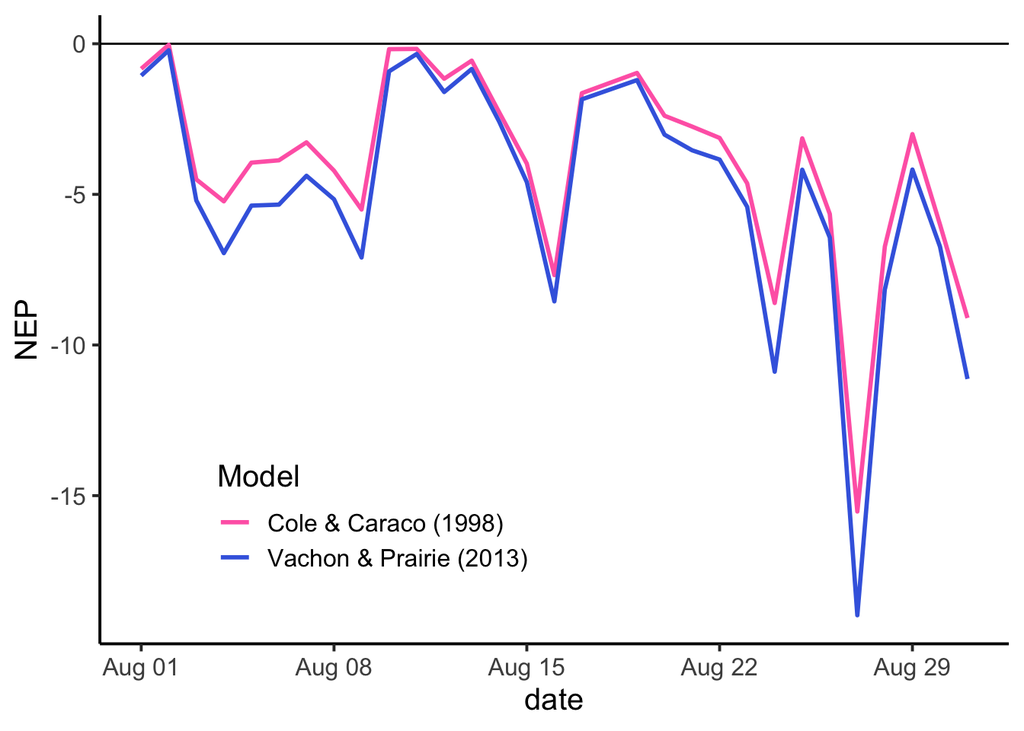

```r
#NEP
ggplot(pondMetabolism.cole, aes(x = date, y = NEP))+
  geom_hline(yintercept = 0)+
  geom_line(aes(color = "hotpink"), size=1)+
  geom_line(data =  pondMetabolism.vachon, aes(x = date, y = NEP, color = "royalblue"), linewidth=1)+
  scale_color_manual(name = 'Model',labels = c('Cole & Caraco (1998)','Vachon & Prairie (2013)'),
         values =c('hotpink'='hotpink','royalblue'='royalblue'))+
  theme_classic(base_size = 15) + theme(legend.position = c(0.3,0.2))
```

```r
#We can look at number of days outside of acceptable range
sum(pondMetabolism.cole$GPP<0)
```

```
## [1] 6
```

```r
sum(pondMetabolism.vachon$GPP<0)
```

```
## [1] 7
```

```r
sum(pondMetabolism.cole$ER>0)
```

```
## [1] 0
```

```r
sum(pondMetabolism.vachon$ER>0)
```

```
## [1] 0
```

More to come here soon!